# Project- Supervised Learning - PersonalLoanCampaignModelling_Subrat Muruni_05.29

## Thera Bank Personal Loan Campaign

### Data Description:

The file Bank.xls contains data on 5000 customers. The data include customer demographic information (age, income, etc.), the customer's relationship with the bank (mortgage, securities account, etc.), and the customer response to the last personal loan campaign (Personal Loan). Among these 5000 customers, only 480 (= 9.6%) accepted the personal loan that was offered to them in the earlier campaign.

### Domain:

Banking

### Context:

This case is about a bank (Thera Bank) whose management wants to explore ways of converting its liability customers to personal loan customers (while retaining them as depositors). A campaign that the bank ran last year for liability customers showed a healthy conversion rate of over 9% success. This has encouraged the retail marketing department to devise campaigns with better target marketing to increase the success ratio with a minimal budget.

### Attribute Information:

- Customer ID
- Age: Customer's age in completed years
- Experience: #years of professional experience
- Income: Annual income of the customer
- ZIP Code: Home Address ZIP code.
- Family: Family size of the customer
- CCAvg: Avg. spending on credit cards per month
- Education: Education Level. 1: Undergrad; 2: Graduate; 3: Advanced/Professional
- Mortgage: Value of house mortgage if any
- Personal Loan: Did this customer accept the personal loan offered in the last campaign?
- Securities Account: Does the customer have a securities account with the bank?
- CD Account: Does the customer have a certificate of deposit (CD) account with the bank?
- Online: Does the customer use internet banking facilities?
- Credit card: Does the customer use a credit card issued by the bank?

### Learning Outcomes:

- Exploratory Data Analysis
- Preparing the data to train a model
- Training and making predictions using a classification model  Modelevaluation

### Objective:

The classification goal is to predict the likelihood of a liability customer buying personal loans.

## GitHub repository URL

### https://github.com/GreatLearningAIML1/gl-pgp-aiml-uta-intl-apr20-SubratMuruni.git

## 1. Import the datasets and libraries, check datatype, statistical summary, shape, null values or incorrect imputation. (5 marks)

##### 1.1 Importing essential libraires

```python
# Import all essential python libraries

import numpy as np # Importing Numpy
import pandas as pd # Importing Pandas
import scipy.stats as stats # Importing Scipy for statistical operations
import matplotlib.pyplot as plt # Importing Matplotlib
import seaborn as sns # Importing Seaborn
sns.set(color_codes = True) # setting the background of the visualization graph
%matplotlib inline
import warnings
warnings.filterwarnings('ignore')
from PIL import Image
from sklearn.preprocessing import LabelEncoder,OneHotEncoder # Importing functions from Sklearn for dummy variables
```

##### 1.2 Importing dataset

```python
# Read the file in a dataframe

dfPersonalLoan = pd.read_csv('/Users/subratmuruni/desktop/Data Science/Projects_Assignments/Project_1_dataset/Bank_Personal_Loan_Modelling.csv')

dfPersonalLoan.head() # Prints the first 5 rows of the dataframe
```

|  | ID | Age | Experience | Income | ZIP Code | Family | CCAvg | Education | Mortgage | Personal Loan | Securities Account | CD Account | Online | CreditCard |
| --- | --- | --- | --- | --- | --- | --- | --- | --- | --- | --- | --- | --- | --- | --- |
| 0 | 1 | 25 | 1 | 49 | 91107 | 4 | 1.6 | 1 | 0 | 0 | 1 | 0 | 0 | 0 |
| 1 | 2 | 45 | 19 | 34 | 90089 | 3 | 1.5 | 1 | 0 | 0 | 1 | 0 | 0 | 0 |
| 2 | 3 | 39 | 15 | 11 | 94720 | 1 | 1.0 | 1 | 0 | 0 | 0 | 0 | 0 | 0 |
| 3 | 4 | 35 | 9 | 100 | 94112 | 1 | 2.7 | 2 | 0 | 0 | 0 | 0 | 0 | 0 |
| 4 | 5 | 35 | 8 | 45 | 91330 | 4 | 1.0 | 2 | 0 | 0 | 0 | 0 | 0 | 1 |

##### 1.3 Checking the datatype of each column

```python
# Check for datatypes in the dataframe

dfPersonalLoan.dtypes # prints the data type of each series
```

```
ID                      int64
Age                     int64
Experience              int64
Income                  int64
ZIP Code                int64
Family                  int64
CCAvg                 float64
Education               int64
Mortgage                int64
Personal Loan           int64
Securities Account      int64
CD Account              int64
Online                  int64
CreditCard              int64
dtype: object
```

##### 1.4 Statistical Summary of the dataset

```python
# finding the statistical summary of the dataframe

dfPersonalLoan.describe()

# Indicates that there are negative (-ve) values for Experience
```

|  | ID | Age | Experience | Income | ZIP Code | Family | CCAvg | Education | Mortgage | Personal Loan | Securities Account | CD Account | Online | CreditCard |
| --- | --- | --- | --- | --- | --- | --- | --- | --- | --- | --- | --- | --- | --- | --- |
| count | 5000.000000 | 5000.000000 | 5000.000000 | 5000.000000 | 5000.000000 | 5000.000000 | 5000.000000 | 5000.000000 | 5000.000000 | 5000.000000 | 5000.000000 | 5000.00000 | 5000.000000 | 5000.000000 |
| mean | 2500.500000 | 45.338400 | 20.104600 | 73.774200 | 93152.503000 | 2.396400 | 1.937938 | 1.881000 | 56.498800 | 0.096000 | 0.104400 | 0.06040 | 0.596800 | 0.294000 |
| std | 1443.520003 | 11.463166 | 11.467954 | 46.033729 | 2121.852197 | 1.147663 | 1.747659 | 0.839869 | 101.713802 | 0.294621 | 0.305809 | 0.23825 | 0.490589 | 0.455637 |
| min | 1.000000 | 23.000000 | -3.000000 | 8.000000 | 9307.000000 | 1.000000 | 0.000000 | 1.000000 | 0.000000 | 0.000000 | 0.000000 | 0.00000 | 0.000000 | 0.000000 |
| 25% | 1250.750000 | 35.000000 | 10.000000 | 39.000000 | 91911.000000 | 1.000000 | 0.700000 | 1.000000 | 0.000000 | 0.000000 | 0.000000 | 0.00000 | 0.000000 | 0.000000 |
| 50% | 2500.500000 | 45.000000 | 20.000000 | 64.000000 | 93437.000000 | 2.000000 | 1.500000 | 2.000000 | 0.000000 | 0.000000 | 0.000000 | 0.00000 | 1.000000 | 0.000000 |
| 75% | 3750.250000 | 55.000000 | 30.000000 | 98.000000 | 94608.000000 | 3.000000 | 2.500000 | 3.000000 | 101.000000 | 0.000000 | 0.000000 | 0.00000 | 1.000000 | 1.000000 |
| max | 5000.000000 | 67.000000 | 43.000000 | 224.000000 | 96651.000000 | 4.000000 | 10.000000 | 3.000000 | 635.000000 | 1.000000 | 1.000000 | 1.00000 | 1.000000 | 1.000000 |

##### 1.5 Shape of dataset

```python
# finding the shape of the dataframe

dfPersonalLoan.shape # dataset has 5000 rows and 14 columns
```

```
(5000, 14)
```

```python
# finding the columns of the dataframe

dfPersonalLoan.columns
```

```
Index(['ID', 'Age', 'Experience', 'Income', 'ZIP Code', 'Family', 'CCAvg',
       'Education', 'Mortgage', 'Personal Loan', 'Securities Account',
       'CD Account', 'Online', 'CreditCard'],
      dtype='object')
```

```python
# finding the information about the dataframe regarding null values & datattype

dfPersonalLoan.info()
```

```
<class 'pandas.core.frame.DataFrame'>
RangeIndex: 5000 entries, 0 to 4999
Data columns (total 14 columns):
 #   Column              Non-Null Count  Dtype
---  ------              --------------  -----
 0   ID                  5000 non-null   int64
 1   Age                 5000 non-null   int64
 2   Experience          5000 non-null   int64
 3   Income              5000 non-null   int64
 4   ZIP Code            5000 non-null   int64
 5   Family              5000 non-null   int64
 6   CCAvg               5000 non-null   float64
 7   Education           5000 non-null   int64
 8   Mortgage            5000 non-null   int64
 9   Personal Loan       5000 non-null   int64
 10  Securities Account  5000 non-null   int64
 11  CD Account          5000 non-null   int64
 12  Online              5000 non-null   int64
 13  CreditCard          5000 non-null   int64
dtypes: float64(1), int64(13)
memory usage: 547.0 KB
```

##### 1.6 Check for Null values, Missing values and incorrect imputation

```python
# finding the sum per column of all null values in the dataframe

dfPersonalLoan.isnull().sum() # results show no null values
```

```
ID                    0
Age                   0
Experience            0
Income                0
ZIP Code              0
Family                0
CCAvg                 0
Education             0
Mortgage              0
Personal Loan         0
Securities Account    0
CD Account            0
Online                0
CreditCard            0
dtype: int64
```

```python
# finding the sum per column of all null values in the dataframe

dfPersonalLoan.isnull().any() # results show no null values
```

```
ID                    False
Age                   False
Experience            False
Income                False
ZIP Code              False
Family                False
CCAvg                 False
Education             False
Mortgage              False
Personal Loan         False
Securities Account    False
CD Account            False
Online                False
CreditCard            False
dtype: bool
```

```python
# finding the None, NaN, NA values in the dataframe

dfPersonalLoan.isna().any() # results indicate no None, NaN and NA values
```

```
ID                    False
Age                   False
Experience            False
Income                False
ZIP Code              False
Family                False
CCAvg                 False
Education             False
Mortgage              False
Personal Loan         False
Securities Account    False
CD Account            False
Online                False
CreditCard            False
dtype: bool
```

```python
# finding duplicate entrys in the dataframe

dfPersonalLoan.duplicated().sum() # results show no duplicate values
```

```
0
```

```python
# find whether all values in columns are real or not

dfPersonalLoan[~dfPersonalLoan.applymap(np.isreal).all(1)] # results show that all are real values
```

|  | ID | Age | Experience | Income | ZIP Code | Family | CCAvg | Education | Mortgage | Personal Loan | Securities Account | CD Account | Online | CreditCard |
| --- | --- | --- | --- | --- | --- | --- | --- | --- | --- | --- | --- | --- | --- | --- |

## 2. EDA: Study the data distribution in each attribute and target variable, share your findings (20 marks)

- Number of unique in each column?
- Number of people with zero mortgage?
- Number of people with zero credit card spending per month?
- Value counts of all categorical columns.
- Univariate and Bivariate
- Get data model ready

##### 1. Number of unique in each column?

```python
# Number of unique in each column

dfPersonalLoan.nunique()
```

```
ID                    5000
Age                     45
Experience              47
Income                 162
ZIP Code               467
Family                   4
CCAvg                  108
Education                3
Mortgage               347
Personal Loan            2
Securities Account       2
CD Account               2
Online                   2
CreditCard               2
dtype: int64
```

##### 2. Number of people with zero mortgage?

```python
# Number of people with zero mortgage

df_1 = dfPersonalLoan[dfPersonalLoan['Mortgage'] == 0]

df_1['Mortgage'].value_counts() # there are 3462 people with 0 mortgage
```

```
0    3462
Name: Mortgage, dtype: int64
```

##### 3. Number of people with zero credit card spending per month?

```python
# Number of people with zero credit card spending per month

df_2 = dfPersonalLoan[dfPersonalLoan['CCAvg'] == 0]

df_2['CCAvg'].value_counts() # there are 106 people with 0 CC spending/month
```

```
0.0    106
Name: CCAvg, dtype: int64
```

##### 4. Value counts of all categorical columns

```python
# categorical columns

df_3 = dfPersonalLoan[['Family','Education', 'Personal Loan', 'Securities Account',
       'CD Account', 'Online', 'CreditCard']]

df_3.head()
```

|  | Family | Education | Personal Loan | Securities Account | CD Account | Online | CreditCard |
| --- | --- | --- | --- | --- | --- | --- | --- |
| 0 | 4 | 1 | 0 | 1 | 0 | 0 | 0 |
| 1 | 3 | 1 | 0 | 1 | 0 | 0 | 0 |
| 2 | 1 | 1 | 0 | 0 | 0 | 0 | 0 |
| 3 | 1 | 2 | 0 | 0 | 0 | 0 | 0 |
| 4 | 4 | 2 | 0 | 0 | 0 | 0 | 1 |

```python
# value counts of all categorical columns

print(df_3['Family'].value_counts())
print()
print(df_3['Education'].value_counts())
print()
print(df_3['Personal Loan'].value_counts())
print()
print(df_3['Securities Account'].value_counts())
print()
print(df_3['CD Account'].value_counts())
print()
print(df_3['Online'].value_counts())
print()
print(df_3['CreditCard'].value_counts())
```

```
1    1472
2    1296
4    1222
3    1010
Name: Family, dtype: int64

1    2096
3    1501
2    1403
Name: Education, dtype: int64

0    4520
1     480
Name: Personal Loan, dtype: int64

0    4478
1     522
Name: Securities Account, dtype: int64

0    4698
1     302
Name: CD Account, dtype: int64

1    2984
0    2016
Name: Online, dtype: int64

0    3530
1    1470
Name: CreditCard, dtype: int64
```

### Univariate analysis

```python
# finding the skewness of data in the dataframe

dfPersonalLoan.skew()
```

```
ID                     0.000000
Age                   -0.029341
Experience            -0.026325
Income                 0.841339
ZIP Code             -12.500221
Family                 0.155221
CCAvg                  1.598443
Education              0.227093
Mortgage               2.104002
Personal Loan          2.743607
Securities Account     2.588268
CD Account             3.691714
Online                -0.394785
CreditCard             0.904589
dtype: float64
```

```python
# IQR of the dataset

IQR = dfPersonalLoan.quantile(0.75)- dfPersonalLoan.quantile(0.25)

IQR
```

```
ID                    2499.5
Age                     20.0
Experience              20.0
Income                  59.0
ZIP Code              2697.0
Family                   2.0
CCAvg                    1.8
Education                2.0
Mortgage               101.0
Personal Loan            0.0
Securities Account       0.0
CD Account               0.0
Online                   1.0
CreditCard               1.0
dtype: float64
```

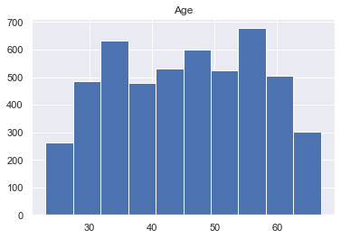

```python
# histogram for Age

dfPersonalLoan.hist('Age');
plt.show()
```

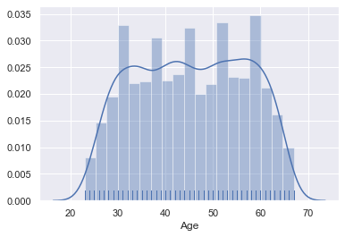

```python
# distplot for Age

sns.distplot(dfPersonalLoan['Age'], rug=True);
plt.show()
```

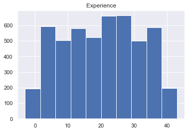

```python
# histogram for Experience

dfPersonalLoan.hist('Experience');
plt.show()
```

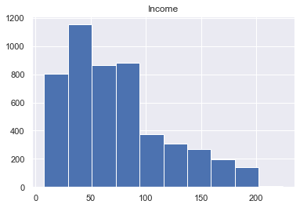

```python
# histogram for Income

dfPersonalLoan.hist('Income');
plt.show()
```

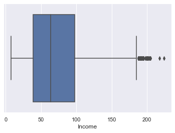

```python
# plotting boxplot for income as an example

sns.boxplot(dfPersonalLoan['Income']);
plt.show()
```

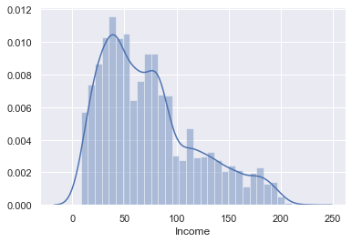

```python
# plotting distplot for income as an example

sns.distplot(dfPersonalLoan['Income']);
plt.show()
```

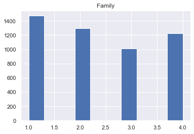

```python
# histogram for family

dfPersonalLoan.hist('Family');
plt.show()
```

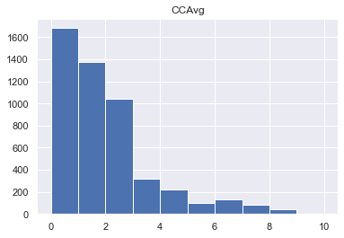

```python
# histogram for credit card average spending

dfPersonalLoan.hist('CCAvg');
plt.show()
```

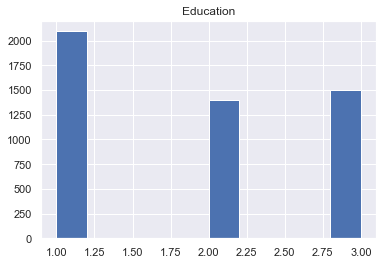

```python
# histogram for education

dfPersonalLoan.hist('Education');
plt.show()
```

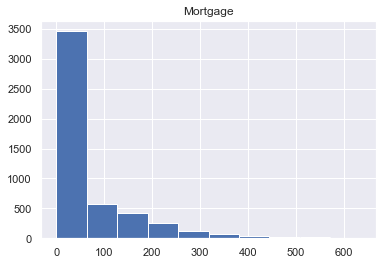

```python
# histogram for Mortgage

dfPersonalLoan.hist('Mortgage');
plt.show()
```

### Bivariate/Multivariate analysis

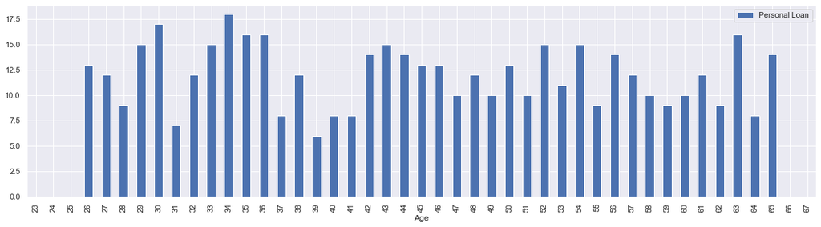

```python
# count of people taking personl loan grouped by age

dfPersonalLoan.groupby(by=['Age'])['Personal Loan'].sum().reset_index().plot(x='Age',
                                                                           y='Personal Loan',
                                                                           kind='bar',
                                                                           figsize=(20,5));
plt.show()
```

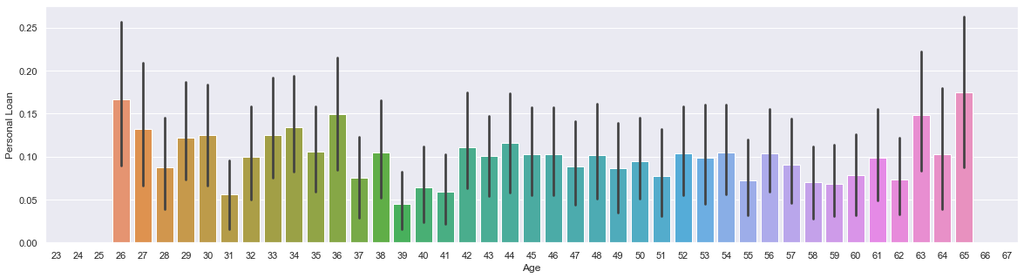

```python
# plotting barplot of the number of people taking personal loan grouped by age

plt.figure(figsize=(20,5))
sns.barplot(x='Age',y='Personal Loan',data=dfPersonalLoan);
plt.show()
```

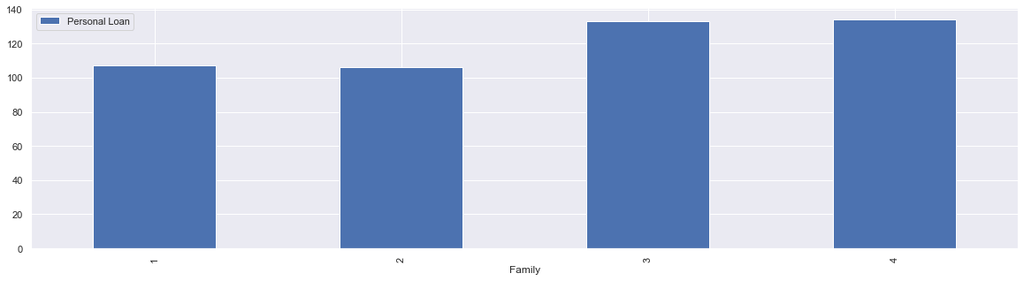

```python
# count of people taking personl loan grouped by number of family members

dfPersonalLoan.groupby(by=['Family'])['Personal Loan'].sum().reset_index().plot(x='Family',
                                                                             y='Personal Loan',
                                                                             kind='bar',
                                                                            figsize=(20,5));
plt.show()
```

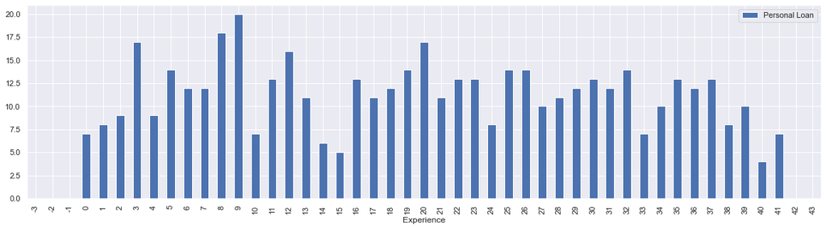

```python
# count of people taking personl loan grouped by Experience

dfPersonalLoan.groupby(by=['Experience'])['Personal Loan'].sum().reset_index().plot(x='Experience',
                                                                             y='Personal Loan',
                                                                             kind='bar',
                                                                            figsize=(20,5));
plt.show()
```

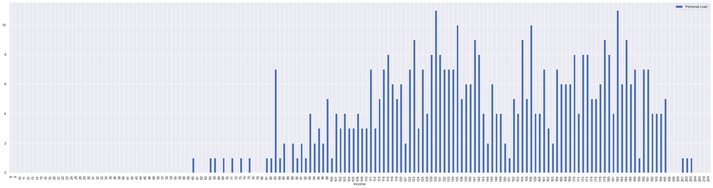

```python
# count of people taking personl loan grouped by Income

dfPersonalLoan.groupby(by=['Income'])['Personal Loan'].sum().reset_index().plot(x='Income',
                                                                             y='Personal Loan',
                                                                             kind='bar',
                                                                            figsize=(40,10));
plt.show()
```

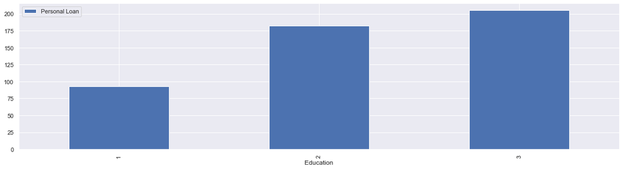

```python
# count of people taking personl loan grouped by Education

dfPersonalLoan.groupby(by=['Education'])['Personal Loan'].sum().reset_index().plot(x='Education',
                                                                             y='Personal Loan',
                                                                             kind='bar',
                                                                            figsize=(20,5));
plt.show()
```

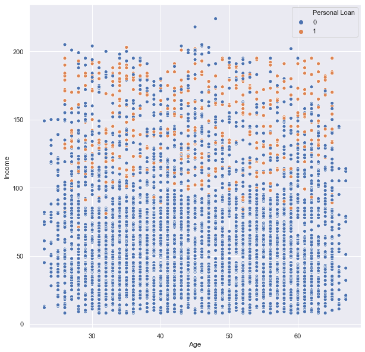

```python
# scatter plot between Age, income with hue personal loan

plt.figure(figsize=(10,10))
sns.scatterplot(dfPersonalLoan['Age'],dfPersonalLoan['Income'], hue = dfPersonalLoan['Personal Loan']);
plt.show()
```

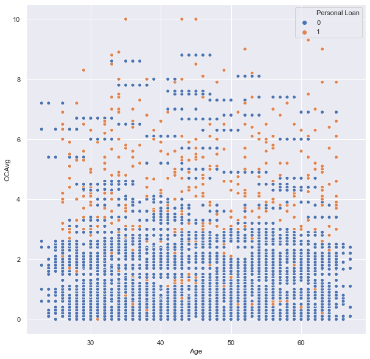

```python
# scatter plot between Age, CCAvg with hue personal loan

plt.figure(figsize=(10,10))
sns.scatterplot(dfPersonalLoan['Age'],dfPersonalLoan['CCAvg'], hue = dfPersonalLoan['Personal Loan']);
plt.show()
```

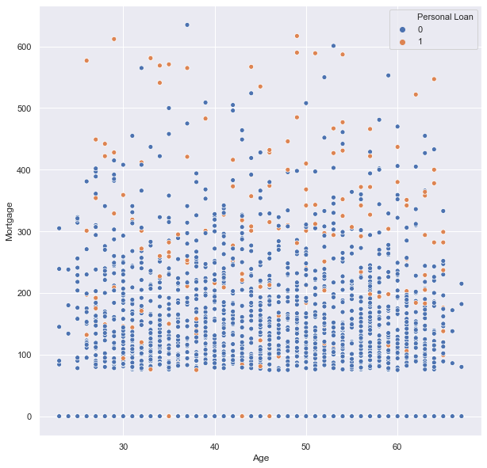

```python
# scatter plot between Age, Mortgage with hue personal loan

plt.figure(figsize=(10,10))
sns.scatterplot(dfPersonalLoan['Age'],dfPersonalLoan['Mortgage'], hue = dfPersonalLoan['Personal Loan']);
plt.show()
```

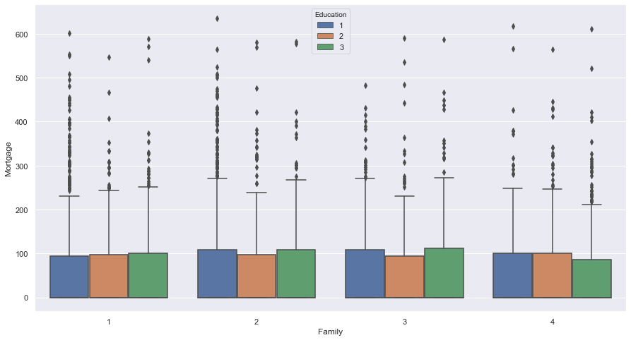

```python
# boxplot between Family and mortgage based on education

plt.figure(figsize=(15,8))
sns.boxplot(x='Family',y='Mortgage', data=dfPersonalLoan, hue='Education');
plt.show()
```

```python
# create a new dataframe 'dfPersonalLoanNew' by dropping Customer ID and ZIP Code
# finding the correlation between attributes

dfPersonalLoanNew = dfPersonalLoan[['Age', 'Experience', 'Income', 'Family', 'CCAvg',
       'Education', 'Mortgage', 'Personal Loan', 'Securities Account',
       'CD Account','Online','CreditCard']]

corr = dfPersonalLoanNew.corr() # assigning variable corr as the correlation function output

corr
```

|  | Age | Experience | Income | Family | CCAvg | Education | Mortgage | Personal Loan | Securities Account | CD Account | Online | CreditCard |
| --- | --- | --- | --- | --- | --- | --- | --- | --- | --- | --- | --- | --- |
| Age | 1.000000 | 0.994215 | -0.055269 | -0.046418 | -0.052012 | 0.041334 | -0.012539 | -0.007726 | -0.000436 | 0.008043 | 0.013702 | 0.007681 |
| Experience | 0.994215 | 1.000000 | -0.046574 | -0.052563 | -0.050077 | 0.013152 | -0.010582 | -0.007413 | -0.001232 | 0.010353 | 0.013898 | 0.008967 |
| Income | -0.055269 | -0.046574 | 1.000000 | -0.157501 | 0.645984 | -0.187524 | 0.206806 | 0.502462 | -0.002616 | 0.169738 | 0.014206 | -0.002385 |
| Family | -0.046418 | -0.052563 | -0.157501 | 1.000000 | -0.109275 | 0.064929 | -0.020445 | 0.061367 | 0.019994 | 0.014110 | 0.010354 | 0.011588 |
| CCAvg | -0.052012 | -0.050077 | 0.645984 | -0.109275 | 1.000000 | -0.136124 | 0.109905 | 0.366889 | 0.015086 | 0.136534 | -0.003611 | -0.006689 |
| Education | 0.041334 | 0.013152 | -0.187524 | 0.064929 | -0.136124 | 1.000000 | -0.033327 | 0.136722 | -0.010812 | 0.013934 | -0.015004 | -0.011014 |
| Mortgage | -0.012539 | -0.010582 | 0.206806 | -0.020445 | 0.109905 | -0.033327 | 1.000000 | 0.142095 | -0.005411 | 0.089311 | -0.005995 | -0.007231 |
| Personal Loan | -0.007726 | -0.007413 | 0.502462 | 0.061367 | 0.366889 | 0.136722 | 0.142095 | 1.000000 | 0.021954 | 0.316355 | 0.006278 | 0.002802 |
| Securities Account | -0.000436 | -0.001232 | -0.002616 | 0.019994 | 0.015086 | -0.010812 | -0.005411 | 0.021954 | 1.000000 | 0.317034 | 0.012627 | -0.015028 |
| CD Account | 0.008043 | 0.010353 | 0.169738 | 0.014110 | 0.136534 | 0.013934 | 0.089311 | 0.316355 | 0.317034 | 1.000000 | 0.175880 | 0.278644 |
| Online | 0.013702 | 0.013898 | 0.014206 | 0.010354 | -0.003611 | -0.015004 | -0.005995 | 0.006278 | 0.012627 | 0.175880 | 1.000000 | 0.004210 |
| CreditCard | 0.007681 | 0.008967 | -0.002385 | 0.011588 | -0.006689 | -0.011014 | -0.007231 | 0.002802 | -0.015028 | 0.278644 | 0.004210 | 1.000000 |

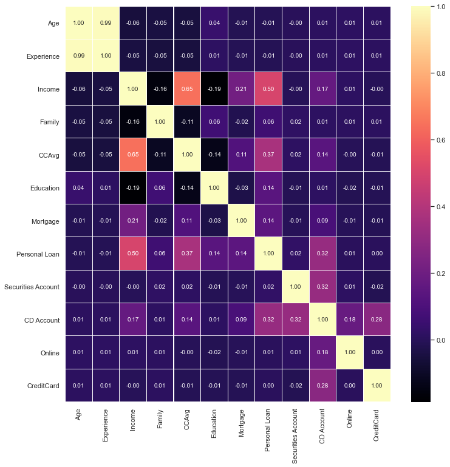

```python
# plotting heatmap for the correlation

plt.figure(figsize=(12,12))

sns.heatmap(corr, annot=True, linewidth=0.05, fmt='0.2f',cmap ='magma');
plt.show()
```

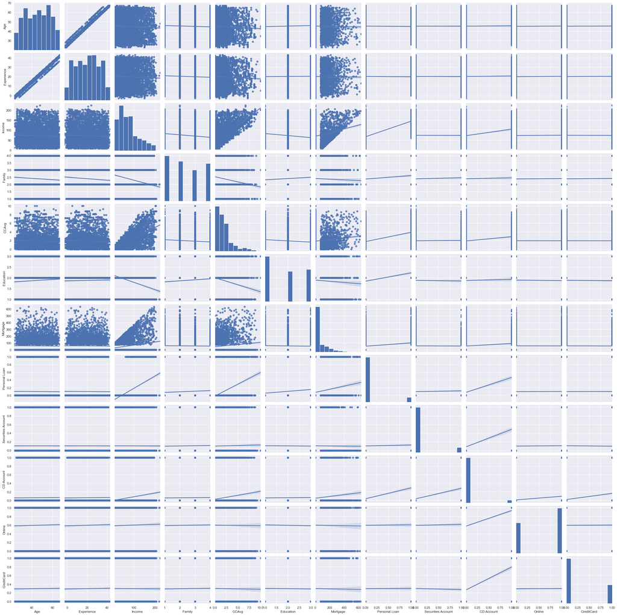

```python
# pair plot between two variables of the dataframe

sns.pairplot(dfPersonalLoanNew, kind ='reg');

plt.show()
```

## Get Data Model Ready

### Data Model -1

##### Steps for creating the optimzed data model

1. Drop customer ID and Zip code columns as they don't add any significane in predicting the success ratio
2. Replace the categorical values of Education
3. Impute -ve values of Experience column with absolute values
4. Get dummies for categorical columns which don't have (0,1) values
5. Drop additional columns which will not add value to the model

```python
# dropping columns Customer ID and ZIP code from the dataset.
# resulting dataframe is 'dfPersonalLoanNew', consisiting of 12 columns

dfPersonalLoanNew.head()
```

|  | Age | Experience | Income | Family | CCAvg | Education | Mortgage | Personal Loan | Securities Account | CD Account | Online | CreditCard |
| --- | --- | --- | --- | --- | --- | --- | --- | --- | --- | --- | --- | --- |
| 0 | 25 | 1 | 49 | 4 | 1.6 | 1 | 0 | 0 | 1 | 0 | 0 | 0 |
| 1 | 45 | 19 | 34 | 3 | 1.5 | 1 | 0 | 0 | 1 | 0 | 0 | 0 |
| 2 | 39 | 15 | 11 | 1 | 1.0 | 1 | 0 | 0 | 0 | 0 | 0 | 0 |
| 3 | 35 | 9 | 100 | 1 | 2.7 | 2 | 0 | 0 | 0 | 0 | 0 | 0 |
| 4 | 35 | 8 | 45 | 4 | 1.0 | 2 | 0 | 0 | 0 | 0 | 0 | 1 |

```python
# finding the shape of the new dataframe

dfPersonalLoanNew.shape # the new dataframe has 5000 rows and 12 columns
```

```
(5000, 12)
```

```python
# finding the negative (-ve) values of Experience

dfPersonalLoan['Experience'].unique()
```

```
array([ 1, 19, 15,  9,  8, 13, 27, 24, 10, 39,  5, 23, 32, 41, 30, 14, 18,
       21, 28, 31, 11, 16, 20, 35,  6, 25,  7, 12, 26, 37, 17,  2, 36, 29,
        3, 22, -1, 34,  0, 38, 40, 33,  4, -2, 42, -3, 43])
```

```python
# imputing the negative (-ve) values of Experience with Absolute values.
# there are three -ve values -1,-2,-3

df1 = dfPersonalLoanNew.copy() # copied the dataframe in a new dataframe for imputation operation

df1.info()
```

```
<class 'pandas.core.frame.DataFrame'>
RangeIndex: 5000 entries, 0 to 4999
Data columns (total 12 columns):
 #   Column              Non-Null Count  Dtype
---  ------              --------------  -----
 0   Age                 5000 non-null   int64
 1   Experience          5000 non-null   int64
 2   Income              5000 non-null   int64
 3   Family              5000 non-null   int64
 4   CCAvg               5000 non-null   float64
 5   Education           5000 non-null   int64
 6   Mortgage            5000 non-null   int64
 7   Personal Loan       5000 non-null   int64
 8   Securities Account  5000 non-null   int64
 9   CD Account          5000 non-null   int64
 10  Online              5000 non-null   int64
 11  CreditCard          5000 non-null   int64
dtypes: float64(1), int64(11)
memory usage: 468.9 KB
```

```python
# imputing the negative vlaues of Experience with Absolute Values.

df1['Experience'] = df1['Experience'].replace({-1:'1', -2:'2', -3:'3'})
```

```python
df1['Experience'].unique()
```

```
array([1, 19, 15, 9, 8, 13, 27, 24, 10, 39, 5, 23, 32, 41, 30, 14, 18, 21,
       28, 31, 11, 16, 20, 35, 6, 25, 7, 12, 26, 37, 17, 2, 36, 29, 3, 22,
       '1', 34, 0, 38, 40, 33, 4, '2', 42, '3', 43], dtype=object)
```

```python
# changing the datatype of the Experience column because regression model can't work on object datatype.

df1 = df1.astype({'Experience':int})

df1.info()
```

```
<class 'pandas.core.frame.DataFrame'>
RangeIndex: 5000 entries, 0 to 4999
Data columns (total 12 columns):
 #   Column              Non-Null Count  Dtype
---  ------              --------------  -----
 0   Age                 5000 non-null   int64
 1   Experience          5000 non-null   int64
 2   Income              5000 non-null   int64
 3   Family              5000 non-null   int64
 4   CCAvg               5000 non-null   float64
 5   Education           5000 non-null   int64
 6   Mortgage            5000 non-null   int64
 7   Personal Loan       5000 non-null   int64
 8   Securities Account  5000 non-null   int64
 9   CD Account          5000 non-null   int64
 10  Online              5000 non-null   int64
 11  CreditCard          5000 non-null   int64
dtypes: float64(1), int64(11)
memory usage: 468.9 KB
```

```python
# replacing the Education column values with categorical values

df1['Education'] = df1['Education'].replace({1:'Undergrad',2:'Graduate',3:'Professional'})
```

```python
# checking the resulting dataframe created.

df1.info() # note that there is an object datatype for 'Education'
```

```
<class 'pandas.core.frame.DataFrame'>
RangeIndex: 5000 entries, 0 to 4999
Data columns (total 12 columns):
 #   Column              Non-Null Count  Dtype
---  ------              --------------  -----
 0   Age                 5000 non-null   int64
 1   Experience          5000 non-null   int64
 2   Income              5000 non-null   int64
 3   Family              5000 non-null   int64
 4   CCAvg               5000 non-null   float64
 5   Education           5000 non-null   object
 6   Mortgage            5000 non-null   int64
 7   Personal Loan       5000 non-null   int64
 8   Securities Account  5000 non-null   int64
 9   CD Account          5000 non-null   int64
 10  Online              5000 non-null   int64
 11  CreditCard          5000 non-null   int64
dtypes: float64(1), int64(10), object(1)
memory usage: 468.9+ KB
```

```python
# use get_dummies function for categorical columns Education and Family
# get_dummies function also changes the object datatype into int

df1_new = pd.get_dummies(df1, columns=['Family','Education'])

df1_new.head()
```

|  | Age | Experience | Income | CCAvg | Mortgage | Personal Loan | Securities Account | CD Account | Online | CreditCard | Family_1 | Family_2 | Family_3 | Family_4 | Education_Graduate | Education_Professional | Education_Undergrad |
| --- | --- | --- | --- | --- | --- | --- | --- | --- | --- | --- | --- | --- | --- | --- | --- | --- | --- |
| 0 | 25 | 1 | 49 | 1.6 | 0 | 0 | 1 | 0 | 0 | 0 | 0 | 0 | 0 | 1 | 0 | 0 | 1 |
| 1 | 45 | 19 | 34 | 1.5 | 0 | 0 | 1 | 0 | 0 | 0 | 0 | 0 | 1 | 0 | 0 | 0 | 1 |
| 2 | 39 | 15 | 11 | 1.0 | 0 | 0 | 0 | 0 | 0 | 0 | 1 | 0 | 0 | 0 | 0 | 0 | 1 |
| 3 | 35 | 9 | 100 | 2.7 | 0 | 0 | 0 | 0 | 0 | 0 | 1 | 0 | 0 | 0 | 1 | 0 | 0 |
| 4 | 35 | 8 | 45 | 1.0 | 0 | 0 | 0 | 0 | 0 | 1 | 0 | 0 | 0 | 1 | 1 | 0 | 0 |

```python
# shape of the resulting dataframe

df1_new.shape
```

```
(5000, 17)
```

```python
# drop columns 'Education_Professional' and 'Family_4' as they don't add value to the model

df2 = df1_new.drop(['Family_4','Education_Professional'], axis=1)

df2.info() # notice that all the columns are numerical values
```

```
<class 'pandas.core.frame.DataFrame'>
RangeIndex: 5000 entries, 0 to 4999
Data columns (total 15 columns):
 #   Column               Non-Null Count  Dtype
---  ------               --------------  -----
 0   Age                  5000 non-null   int64
 1   Experience           5000 non-null   int64
 2   Income               5000 non-null   int64
 3   CCAvg                5000 non-null   float64
 4   Mortgage             5000 non-null   int64
 5   Personal Loan        5000 non-null   int64
 6   Securities Account   5000 non-null   int64
 7   CD Account           5000 non-null   int64
 8   Online               5000 non-null   int64
 9   CreditCard           5000 non-null   int64
 10  Family_1             5000 non-null   uint8
 11  Family_2             5000 non-null   uint8
 12  Family_3             5000 non-null   uint8
 13  Education_Graduate   5000 non-null   uint8
 14  Education_Undergrad  5000 non-null   uint8
dtypes: float64(1), int64(9), uint8(5)
memory usage: 415.2 KB
```

```python
# store the resulting dataset in a new dataframe 'dfModel_1'

dfModel_1 = df2.copy()

dfModel_1.head()
```

|  | Age | Experience | Income | CCAvg | Mortgage | Personal Loan | Securities Account | CD Account | Online | CreditCard | Family_1 | Family_2 | Family_3 | Education_Graduate | Education_Undergrad |
| --- | --- | --- | --- | --- | --- | --- | --- | --- | --- | --- | --- | --- | --- | --- | --- |
| 0 | 25 | 1 | 49 | 1.6 | 0 | 0 | 1 | 0 | 0 | 0 | 0 | 0 | 0 | 0 | 1 |
| 1 | 45 | 19 | 34 | 1.5 | 0 | 0 | 1 | 0 | 0 | 0 | 0 | 0 | 1 | 0 | 1 |
| 2 | 39 | 15 | 11 | 1.0 | 0 | 0 | 0 | 0 | 0 | 0 | 1 | 0 | 0 | 0 | 1 |
| 3 | 35 | 9 | 100 | 2.7 | 0 | 0 | 0 | 0 | 0 | 0 | 1 | 0 | 0 | 1 | 0 |
| 4 | 35 | 8 | 45 | 1.0 | 0 | 0 | 0 | 0 | 0 | 1 | 0 | 0 | 0 | 1 | 0 |

```python
# checking that the resulting dataframe doesn't have object datatype

dfModel_1.info()
```

```
<class 'pandas.core.frame.DataFrame'>
RangeIndex: 5000 entries, 0 to 4999
Data columns (total 15 columns):
 #   Column               Non-Null Count  Dtype
---  ------               --------------  -----
 0   Age                  5000 non-null   int64
 1   Experience           5000 non-null   int64
 2   Income               5000 non-null   int64
 3   CCAvg                5000 non-null   float64
 4   Mortgage             5000 non-null   int64
 5   Personal Loan        5000 non-null   int64
 6   Securities Account   5000 non-null   int64
 7   CD Account           5000 non-null   int64
 8   Online               5000 non-null   int64
 9   CreditCard           5000 non-null   int64
 10  Family_1             5000 non-null   uint8
 11  Family_2             5000 non-null   uint8
 12  Family_3             5000 non-null   uint8
 13  Education_Graduate   5000 non-null   uint8
 14  Education_Undergrad  5000 non-null   uint8
dtypes: float64(1), int64(9), uint8(5)
memory usage: 415.2 KB
```

```python
# statistical summary of the resulting data model

dfModel_1.describe()
```

|  | Age | Experience | Income | CCAvg | Mortgage | Personal Loan | Securities Account | CD Account | Online | CreditCard | Family_1 | Family_2 | Family_3 | Education_Graduate | Education_Undergrad |
| --- | --- | --- | --- | --- | --- | --- | --- | --- | --- | --- | --- | --- | --- | --- | --- |
| count | 5000.000000 | 5000.000000 | 5000.000000 | 5000.000000 | 5000.000000 | 5000.000000 | 5000.000000 | 5000.00000 | 5000.000000 | 5000.000000 | 5000.000000 | 5000.000000 | 5000.000000 | 5000.000000 | 5000.000000 |
| mean | 45.338400 | 20.134600 | 73.774200 | 1.937938 | 56.498800 | 0.096000 | 0.104400 | 0.06040 | 0.596800 | 0.294000 | 0.294400 | 0.259200 | 0.202000 | 0.280600 | 0.419200 |
| std | 11.463166 | 11.415189 | 46.033729 | 1.747659 | 101.713802 | 0.294621 | 0.305809 | 0.23825 | 0.490589 | 0.455637 | 0.455818 | 0.438239 | 0.401532 | 0.449337 | 0.493478 |
| min | 23.000000 | 0.000000 | 8.000000 | 0.000000 | 0.000000 | 0.000000 | 0.000000 | 0.00000 | 0.000000 | 0.000000 | 0.000000 | 0.000000 | 0.000000 | 0.000000 | 0.000000 |
| 25% | 35.000000 | 10.000000 | 39.000000 | 0.700000 | 0.000000 | 0.000000 | 0.000000 | 0.00000 | 0.000000 | 0.000000 | 0.000000 | 0.000000 | 0.000000 | 0.000000 | 0.000000 |
| 50% | 45.000000 | 20.000000 | 64.000000 | 1.500000 | 0.000000 | 0.000000 | 0.000000 | 0.00000 | 1.000000 | 0.000000 | 0.000000 | 0.000000 | 0.000000 | 0.000000 | 0.000000 |
| 75% | 55.000000 | 30.000000 | 98.000000 | 2.500000 | 101.000000 | 0.000000 | 0.000000 | 0.00000 | 1.000000 | 1.000000 | 1.000000 | 1.000000 | 0.000000 | 1.000000 | 1.000000 |
| max | 67.000000 | 43.000000 | 224.000000 | 10.000000 | 635.000000 | 1.000000 | 1.000000 | 1.00000 | 1.000000 | 1.000000 | 1.000000 | 1.000000 | 1.000000 | 1.000000 | 1.000000 |

```python
# finding out if the dataset is balanced or imbalanced

dfModel_1['Personal Loan'].value_counts(normalize=True)
```

```
0    0.904
1    0.096
Name: Personal Loan, dtype: float64
```

The resulting data model is a imbalanced data set with class-1 at 10% and class-0 at 90%. Analysis must be done to improve the data model balance and see if class-1 % can be imporved.

### Data Model - 2

##### Steps for creating the optimzed data model where the customer has relationship with bank

1. Drop customer ID and Zip code columns as they don't add any significane in predicting the success ratio
2. Replace the categorical values of Education
3. Impute -ve values of Experience column with absolute values
4. Get dummies for categorical columns which don't have (0,1) values
5. Dropping 801 rows which don't have any relationship with the bank

```python
# checking that the total count of people who accepted Personal Loan in the original data set

df2['Personal Loan'].value_counts()
```

```
0    4520
1     480
Name: Personal Loan, dtype: int64
```

```python
# creating a new data set with only customers who have relationship with bank

dfModel_2 = df2[(df2['Personal Loan']==1)
                               |(df2['Securities Account']==1)
                               |(df2['CD Account']==1)
                               |(df2['Online']==1)
                               |(df2['CreditCard']==1)
                               |(df2['Mortgage']!=0)]

dfModel_2.info()
```

```
<class 'pandas.core.frame.DataFrame'>
Int64Index: 4199 entries, 0 to 4999
Data columns (total 15 columns):
 #   Column               Non-Null Count  Dtype
---  ------               --------------  -----
 0   Age                  4199 non-null   int64
 1   Experience           4199 non-null   int64
 2   Income               4199 non-null   int64
 3   CCAvg                4199 non-null   float64
 4   Mortgage             4199 non-null   int64
 5   Personal Loan        4199 non-null   int64
 6   Securities Account   4199 non-null   int64
 7   CD Account           4199 non-null   int64
 8   Online               4199 non-null   int64
 9   CreditCard           4199 non-null   int64
 10  Family_1             4199 non-null   uint8
 11  Family_2             4199 non-null   uint8
 12  Family_3             4199 non-null   uint8
 13  Education_Graduate   4199 non-null   uint8
 14  Education_Undergrad  4199 non-null   uint8
dtypes: float64(1), int64(9), uint8(5)
memory usage: 381.4 KB
```

```python
# checking the value count of customers who accepted Personal Loan remains the same

dfModel_2['Personal Loan'].value_counts()
```

```
0    3719
1     480
Name: Personal Loan, dtype: int64
```

```python
# checking the information of the new dataframe created

dfModel_2.info()
```

```
<class 'pandas.core.frame.DataFrame'>
Int64Index: 4199 entries, 0 to 4999
Data columns (total 15 columns):
 #   Column               Non-Null Count  Dtype
---  ------               --------------  -----
 0   Age                  4199 non-null   int64
 1   Experience           4199 non-null   int64
 2   Income               4199 non-null   int64
 3   CCAvg                4199 non-null   float64
 4   Mortgage             4199 non-null   int64
 5   Personal Loan        4199 non-null   int64
 6   Securities Account   4199 non-null   int64
 7   CD Account           4199 non-null   int64
 8   Online               4199 non-null   int64
 9   CreditCard           4199 non-null   int64
 10  Family_1             4199 non-null   uint8
 11  Family_2             4199 non-null   uint8
 12  Family_3             4199 non-null   uint8
 13  Education_Graduate   4199 non-null   uint8
 14  Education_Undergrad  4199 non-null   uint8
dtypes: float64(1), int64(9), uint8(5)
memory usage: 381.4 KB
```

```python
# statistical summary of the new data frame 'dfModel_2'

dfModel_2.describe()
```

|  | Age | Experience | Income | CCAvg | Mortgage | Personal Loan | Securities Account | CD Account | Online | CreditCard | Family_1 | Family_2 | Family_3 | Education_Graduate | Education_Undergrad |
| --- | --- | --- | --- | --- | --- | --- | --- | --- | --- | --- | --- | --- | --- | --- | --- |
| count | 4199.000000 | 4199.000000 | 4199.000000 | 4199.000000 | 4199.000000 | 4199.000000 | 4199.000000 | 4199.000000 | 4199.000000 | 4199.000000 | 4199.000000 | 4199.000000 | 4199.000000 | 4199.000000 | 4199.000000 |
| mean | 45.359848 | 20.157180 | 74.999286 | 1.962977 | 67.276494 | 0.114313 | 0.124315 | 0.071922 | 0.710645 | 0.350083 | 0.289116 | 0.259824 | 0.201715 | 0.283401 | 0.413670 |
| std | 11.488475 | 11.433782 | 46.712645 | 1.770012 | 107.677535 | 0.318229 | 0.329980 | 0.258389 | 0.453517 | 0.477053 | 0.453406 | 0.438590 | 0.401328 | 0.450703 | 0.492549 |
| min | 23.000000 | 0.000000 | 8.000000 | 0.000000 | 0.000000 | 0.000000 | 0.000000 | 0.000000 | 0.000000 | 0.000000 | 0.000000 | 0.000000 | 0.000000 | 0.000000 | 0.000000 |
| 25% | 35.000000 | 10.000000 | 39.000000 | 0.700000 | 0.000000 | 0.000000 | 0.000000 | 0.000000 | 0.000000 | 0.000000 | 0.000000 | 0.000000 | 0.000000 | 0.000000 | 0.000000 |
| 50% | 45.000000 | 20.000000 | 64.000000 | 1.500000 | 0.000000 | 0.000000 | 0.000000 | 0.000000 | 1.000000 | 0.000000 | 0.000000 | 0.000000 | 0.000000 | 0.000000 | 0.000000 |
| 75% | 55.000000 | 30.000000 | 101.000000 | 2.600000 | 118.000000 | 0.000000 | 0.000000 | 0.000000 | 1.000000 | 1.000000 | 1.000000 | 1.000000 | 0.000000 | 1.000000 | 1.000000 |
| max | 67.000000 | 43.000000 | 224.000000 | 10.000000 | 635.000000 | 1.000000 | 1.000000 | 1.000000 | 1.000000 | 1.000000 | 1.000000 | 1.000000 | 1.000000 | 1.000000 | 1.000000 |

```python
# finding out if the dataset is balanced or imbalanced

dfModel_2['Personal Loan'].value_counts(normalize=True)
```

```
0    0.885687
1    0.114313
Name: Personal Loan, dtype: float64
```

The resulting data model is a imbalanced data set with class-1 at 11.5% and class-0 at 88.5%. Dropping the rows of customers who don't have any asset or liability product with the bank, didn't improve the class imbalance.

## 3. Split the data into training and test set in the ratio of 70:30 respectively (5 marks)

### Data Model - 1, Split in ratio 70:30

```python
# import the train_test_split function from scikit-learn

from sklearn.model_selection import train_test_split

# dividing the data set in to dependent and independent variables
# all independent variables
x1 = dfModel_1.drop(['Personal Loan'],axis=1)

# Personal Loan column which is dependent variable
y1 = dfModel_1[['Personal Loan']]
```

```python
# splitting the data into ratio 70:30

x1_train, x1_test, y1_train, y1_test = train_test_split(x1,y1,test_size=0.30, random_state=1)

x1_train.shape, x1_test.shape, y1_train.shape, y1_test.shape
```

```
((3500, 14), (1500, 14), (3500, 1), (1500, 1))
```

### Data Model - 2, Split in ratio 70:30

```python
# dividing the data set in to dependent and independent variables

# all independent variables
x2 = dfModel_2.drop(['Personal Loan'],axis=1)

# Personal Loan column which is dependent variable
y2 = dfModel_2[['Personal Loan']]
```

```python
# splitting the data into ratio 70:30

x2_train, x2_test, y2_train, y2_test = train_test_split(x2,y2,test_size=0.30, random_state=1)

x2_train.shape, x2_test.shape, y2_train.shape, y2_test.shape
```

```
((2939, 14), (1260, 14), (2939, 1), (1260, 1))
```

## 4. Use Logistic Regression model to predict the number of a customers buying personal loans. Print all the metrics related for evaluating the model performance (15 marks)

## Logisitic Regression for Data Model - 1

###### Use stats model to find out coefficients, odds ratio and probability

1. Use the stats model to get the coefficients
2. Calculate the odds ratio
3. Calculate the probability

###### Logistic Regression model building

1. Train the model and then test it.
2. Calculate Confusion Matrix, Recall, Precision, AUC, F1 Score
3. Plot the Confusion Matrix in the form of heat map
4. Plot the AUC curve

```python
# build the stats model by importing the library

import statsmodels.api as sm
logit = sm.Logit(y1_train, sm.add_constant(x1_train))
lg = logit.fit()
```

```
Optimization terminated successfully.
         Current function value: 0.107513
         Iterations 10
```

```python
# use the summary function to find the coefficients of independent variables

lg.summary()
```

Logit Regression Results

[output not shown]

|  | coef | std err | z | P>\|z\| | [0.025 | 0.975] |
| --- | --- | --- | --- | --- | --- | --- |
| const | -6.2522 | 2.315 | -2.701 | 0.007 | -10.789 | -1.715 |
| Age | 0.0106 | 0.087 | 0.121 | 0.903 | -0.161 | 0.182 |
| Experience | 0.0088 | 0.087 | 0.101 | 0.920 | -0.163 | 0.180 |
| Income | 0.0637 | 0.004 | 15.691 | 0.000 | 0.056 | 0.072 |
| CCAvg | 0.1837 | 0.059 | 3.110 | 0.002 | 0.068 | 0.299 |
| Mortgage | -0.0012 | 0.001 | -1.551 | 0.121 | -0.003 | 0.000 |
| Securities Account | -1.4689 | 0.366 | -4.014 | 0.000 | -2.186 | -0.752 |
| CD Account | 4.8337 | 0.454 | 10.642 | 0.000 | 3.943 | 5.724 |
| Online | -2.0519 | 0.263 | -7.811 | 0.000 | -2.567 | -1.537 |
| CreditCard | -2.1328 | 0.304 | -7.022 | 0.000 | -2.728 | -1.537 |
| Family_1 | -1.6992 | 0.308 | -5.514 | 0.000 | -2.303 | -1.095 |
| Family_2 | -2.2726 | 0.336 | -6.772 | 0.000 | -2.930 | -1.615 |
| Family_3 | 0.2444 | 0.284 | 0.860 | 0.390 | -0.313 | 0.801 |
| Education_Graduate | -0.1143 | 0.251 | -0.455 | 0.649 | -0.607 | 0.378 |
| Education_Undergrad | -3.4985 | 0.324 | -10.782 | 0.000 | -4.134 | -2.863 |

Possibly complete quasi-separation: A fraction 0.13 of observations can be  
perfectly predicted. This might indicate that there is complete  
quasi-separation. In this case some parameters will not be identified.

```python
# call the parameters i.e coefficients separately.

lg.params
```

```
const                 -6.252197
Age                    0.010594
Experience             0.008835
Income                 0.063667
CCAvg                  0.183682
Mortgage              -0.001224
Securities Account    -1.468884
CD Account             4.833715
Online                -2.051931
CreditCard            -2.132825
Family_1              -1.699152
Family_2              -2.272556
Family_3               0.244394
Education_Graduate    -0.114331
Education_Undergrad   -3.498459
dtype: float64
```

```python
# fetch coefficients of independent variable in a dataframe to compare with odds ratio and probability

lgcoef = pd.DataFrame(lg.params, columns=['coeff'])

lgcoef
```

|  | coeff |
| --- | --- |
| const | -6.252197 |
| Age | 0.010594 |
| Experience | 0.008835 |
| Income | 0.063667 |
| CCAvg | 0.183682 |
| Mortgage | -0.001224 |
| Securities Account | -1.468884 |
| CD Account | 4.833715 |
| Online | -2.051931 |
| CreditCard | -2.132825 |
| Family_1 | -1.699152 |
| Family_2 | -2.272556 |
| Family_3 | 0.244394 |
| Education_Graduate | -0.114331 |
| Education_Undergrad | -3.498459 |

```python
# calculate the odds ratio of the independent variable

lgcoef['odds_ratio'] = lgcoef['coeff'].apply(lambda x: np.exp(x))

lgcoef
```

|  | coeff | odds_ratio |
| --- | --- | --- |
| const | -6.252197 | 0.001926 |
| Age | 0.010594 | 1.010651 |
| Experience | 0.008835 | 1.008874 |
| Income | 0.063667 | 1.065737 |
| CCAvg | 0.183682 | 1.201634 |
| Mortgage | -0.001224 | 0.998777 |
| Securities Account | -1.468884 | 0.230182 |
| CD Account | 4.833715 | 125.676996 |
| Online | -2.051931 | 0.128487 |
| CreditCard | -2.132825 | 0.118502 |
| Family_1 | -1.699152 | 0.182839 |
| Family_2 | -2.272556 | 0.103048 |
| Family_3 | 0.244394 | 1.276848 |
| Education_Graduate | -0.114331 | 0.891963 |
| Education_Undergrad | -3.498459 | 0.030244 |

```python
# calculate the probability of the independent variables

lgcoef['probability'] = lgcoef['odds_ratio']/(1+lgcoef['odds_ratio'])

lgcoef
```

|  | coeff | odds_ratio | probability |
| --- | --- | --- | --- |
| const | -6.252197 | 0.001926 | 0.001923 |
| Age | 0.010594 | 1.010651 | 0.502649 |
| Experience | 0.008835 | 1.008874 | 0.502209 |
| Income | 0.063667 | 1.065737 | 0.515911 |
| CCAvg | 0.183682 | 1.201634 | 0.545792 |
| Mortgage | -0.001224 | 0.998777 | 0.499694 |
| Securities Account | -1.468884 | 0.230182 | 0.187112 |
| CD Account | 4.833715 | 125.676996 | 0.992106 |
| Online | -2.051931 | 0.128487 | 0.113857 |
| CreditCard | -2.132825 | 0.118502 | 0.105947 |
| Family_1 | -1.699152 | 0.182839 | 0.154576 |
| Family_2 | -2.272556 | 0.103048 | 0.093422 |
| Family_3 | 0.244394 | 1.276848 | 0.560796 |
| Education_Graduate | -0.114331 | 0.891963 | 0.471448 |
| Education_Undergrad | -3.498459 | 0.030244 | 0.029356 |

### Logistic Regression Model

```python
# building the logistic regression model

from sklearn.linear_model import LogisticRegression

logreg = LogisticRegression(random_state=42)
logreg.fit(x1_train,y1_train)
```

```
LogisticRegression(C=1.0, class_weight=None, dual=False, fit_intercept=True,
                   intercept_scaling=1, l1_ratio=None, max_iter=100,
                   multi_class='auto', n_jobs=None, penalty='l2',
                   random_state=42, solver='lbfgs', tol=0.0001, verbose=0,
                   warm_start=False)
```

```python
y1_predict = logreg.predict(x1_test)
```

### Printing matrics for evaluating Model performance

#### 4.1. Confusion Matrix

```python
# importing the matrics from scikit-learn for the various logistic regression matrics

from sklearn.metrics import confusion_matrix, recall_score, precision_score, f1_score, roc_auc_score, accuracy_score

from sklearn import metrics

cm = metrics.confusion_matrix(y1_test,y1_predict) # print confusion matrix

print(cm)
```

```
[[1341   10]
 [  56   93]]
```

```python
# plot the confusion matrix in terms of heatmap for better visualization.

def draw_cm(actual,predicted):
    cm = confusion_matrix(actual,predicted)
    sns.heatmap(cm,annot=True, linewidth=0.05, fmt='.2f', xticklabels=[0,1], yticklabels=[0,1])
    plt.ylabel('observed')
    plt.xlabel('Predicted')
    plt.show()
```

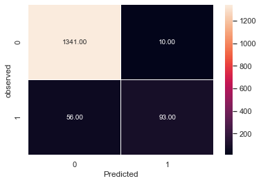

```python
# pass parameters in draw_cm function to plot the heatmap.

draw_cm(y1_test,y1_predict)
```

#### Summary of confusion matrix for model logreg

```python
# True Positive (TP) = 93
# True Negative (TN) = 1341
# False Positive (FP) = 10
# False Negative(FN) = 56
```

#### 4.2. Score comparision between trainging and testing model

```python
# comparing training to testing score

print('Training Score:',logreg.score(x1_train,y1_train))
print('')
print('Testing Score:',logreg.score(x1_test,y1_test))
```

```
Training Score: 0.9617142857142857

Testing Score: 0.956
```

#### 4.3. Recall Score

```python
# recall score of testing model

recall_score(y1_test, y1_predict)
```

```
0.6241610738255033
```

#### 4.4. F1 Score

```python
f1_score(y1_test,y1_predict)
```

```
0.738095238095238
```

#### 4.5. Precision Score

```python
precision_score(y1_test,y1_predict)
```

```
0.9029126213592233
```

#### 4.6. Area under the curve (AUC)

```python
roc_auc_score(y1_test,y1_predict)
```

```
0.8083795746625666
```

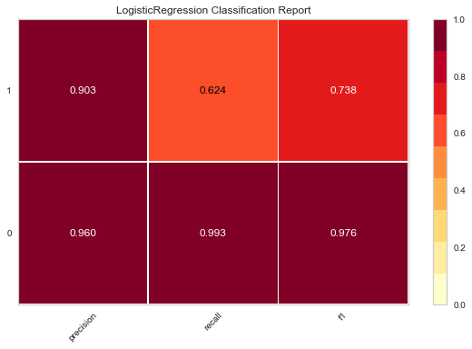

```python
# visualization of confusion matrix using yellowbrick package

from yellowbrick.classifier import ClassificationReport, ROCAUC
viz = ClassificationReport(LogisticRegression(random_state=42))
viz.fit(x1_train,y1_train)
viz.score(x1_test,y1_test)
viz.show();
```

1. The visualization shows that the precision is about 90%
2. Recall is about 62%
3. Number of total people buying the loan is 149
4. Number of people buying the loan successfully predicted by model is 93
5. Number of people buying the loan not predicted by the model is 56

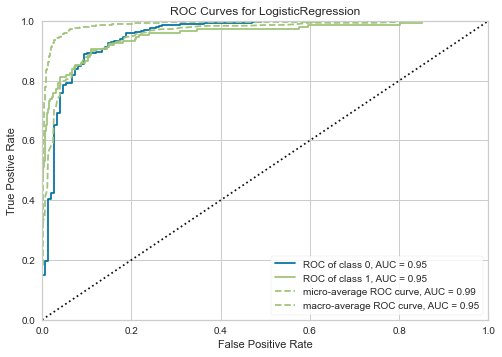

```python
# plotting area under the AUC curve

roc = ROCAUC(LogisticRegression(random_state=42))
roc.fit(x1_train,y1_train)
roc.score(x1_test,y1_test)
roc.show();
```

## 5. Give your reasoning on how can the model perform better? (10 marks) Hint: Check parameter

##### Since we are maximizing the number of people who should be targetted via the campaign for buying the loan we need to improve upon the recall score. This can be done by changing the parameters in the logistic model.

```python
# fetch the parameters of the logistic model from the first iteration to analyze how to improve the model

logreg.get_params()
```

```
{'C': 1.0,
 'class_weight': None,
 'dual': False,
 'fit_intercept': True,
 'intercept_scaling': 1,
 'l1_ratio': None,
 'max_iter': 100,
 'multi_class': 'auto',
 'n_jobs': None,
 'penalty': 'l2',
 'random_state': 42,
 'solver': 'lbfgs',
 'tol': 0.0001,
 'verbose': 0,
 'warm_start': False}
```

```python
# from scikit-learn use the GridSearchCV library to find out the optimum parameters for logistic model

from sklearn.model_selection import GridSearchCV

param_grid = [{'solver': ['newton-cg','lbfgs','liblinear','sag','saga'], 'C': [0.001,0.01,0.1,0.25,0.5,0.75,1],
              'class_weight':['balanced'], 'penalty':['l2']}]


grid_search = GridSearchCV(LogisticRegression(),param_grid,cv=5, verbose=0)
grid_search.fit(x1_train,y1_train)
```

```
GridSearchCV(cv=5, error_score=nan,
             estimator=LogisticRegression(C=1.0, class_weight=None, dual=False,
                                          fit_intercept=True,
                                          intercept_scaling=1, l1_ratio=None,
                                          max_iter=100, multi_class='auto',
                                          n_jobs=None, penalty='l2',
                                          random_state=None, solver='lbfgs',
                                          tol=0.0001, verbose=0,
                                          warm_start=False),
             iid='deprecated', n_jobs=None,
             param_grid=[{'C': [0.001, 0.01, 0.1, 0.25, 0.5, 0.75, 1],
                          'class_weight': ['balanced'], 'penalty': ['l2'],
                          'solver': ['newton-cg', 'lbfgs', 'liblinear', 'sag',
                                     'saga']}],
             pre_dispatch='2*n_jobs', refit=True, return_train_score=False,
             scoring=None, verbose=0)
```

```python
# Multiple interation are run and provides the best estimator of the logistic regression.

grid_search.best_estimator_
```

```
LogisticRegression(C=1, class_weight='balanced', dual=False, fit_intercept=True,
                   intercept_scaling=1, l1_ratio=None, max_iter=100,
                   multi_class='auto', n_jobs=None, penalty='l2',
                   random_state=None, solver='lbfgs', tol=0.0001, verbose=0,
                   warm_start=False)
```

```python
# best logistic model generated by changing the parameters

bestModelLR = LogisticRegression(C=1, class_weight='balanced', dual=False, fit_intercept=True,
                   intercept_scaling=1, l1_ratio=None, max_iter=100,
                   multi_class='auto', n_jobs=None, penalty='l2',
                   random_state=None, solver='lbfgs', tol=0.0001, verbose=0,
                   warm_start=False)
```

```python
# training the new logistic regression model

bestModelLR.fit(x1_train, y1_train)
prediction = bestModelLR.predict(x1_test)
```

###### logreg model had values:

class_weight = None  
random_state =42

###### bestModelLR has values:

class_weight = 'balanced'  
random_state = None

##### Using the new logistic regression model the recall score has improved to 86%. Precesion has dropped but we are trying to minimize the False Negative and hence the recall score.

##### Notice that FN has decreased from 56 to 20.

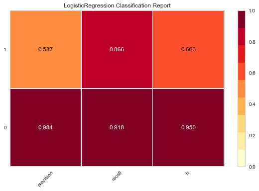

```python
viz = ClassificationReport(bestModelLR)
viz.fit(x1_train,y1_train)
viz.score(x1_test,y1_test)
viz.show();
```

```python
# testing the new logistic regression model

y2_predict = bestModelLR.predict(x1_test)
```

```python
# plotting the confusion matrix for the new logistic regression model

cm_1 = metrics.confusion_matrix(y1_test,y2_predict)

print(cm_1)
```

```
[[1240  111]
 [  20  129]]
```

#### Summary of confusion matrix for model bestModelLR

```python
# True Positive (TP) = 129
# True Negative (TN) = 1240
# False Positive (FP) = 111
# False Negative(FN) = 20
```

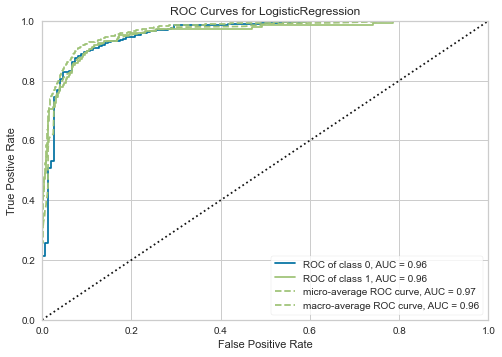

```python
# plotting new area under the curve

roc = ROCAUC(bestModelLR)
roc.fit(x1_train,y1_train)
roc.score(x1_test,y1_test)
roc.show();
```

## 6. Give Business understanding of your model? (5 marks)

### 6.2. Business understanding from Data Model

1. Customer ID and ZIP code don't add any significant value to the model. So dropping these two columns.
2. Although via EDA there is relationship established between the columns, none of them indicate causation. So, a conclusive decision can't be made on dropping these columns. Hence have retained the rest of the columns.
3. For Data Model-1, the resulting data model is a imbalanced data set with class-1 at 10% and class-0 at 90%. An attempt was made to improve the class-1% in the dataset by dropping 801 rows of customers which didn't have any relationship with the bank.
4. For Data Model-2, the resulting data model is a imbalanced data set with class-1 at 11.5% and class-0 at 88.5%. As there is no significant difference, a decision was taken to retain all rows of the dataset.
5. Finally a decision was made to only fit the logistic regression model on the Data Model-1

### 6.3. Business understanding of Logistic regression model

1. From the first iteration of the model, the following observations were made.
   - True Positive (TP) = **93**
   - True Negative (TN) = **1341**
   - False Positive (FP) = **10**
   - False Negative(FN) = **56**
   - Recall = **62%**
   - Precision = **90%**
   - F1 Score = **0.73**
   - AUC = **0.80**

Our objective is to **increase the recall or lower the False Negatives.**  
The premise behind this reasoning is that higher the False Negative numbers, the campaign is not considering attracting certain segment of people who could have been potentially accepted the personal loan offered to them.  
The objective would be to attract/target as many people as possible who can be potential personal loan applicants.  
The bank considers a 9% conversion rate as a healthy rate. Calculating the conversion rate from the True Positive number that the model predicted from a test sample of 1500, turns out to be **6.2%.**</font>  
This is **2.8%** below the conversion rate the bank considers healthy.

1. Performing Model tuning on the Logistic regression model, the following observations were made.
   - True Positive (TP) = **129**
   - True Negative (TN) = **1240**
   - False Positive (FP) = **111**
   - False Negative(FN) = **20**
   - Recall = **86%**
   - Precision = **53%**

After model tuning, the recall has increased by **24%** while the precision has decreased by **37%.** The overall Positive conversions for a sample size of 1500 from the test data set increases to **129** (factoring in reduction in FN predicted by the model)  
Again calculating the conversion rate from the True Positive number that the model predicted from a test sample of 1500, turns out to be **8.6%.**. This is very close to the conversion percentage the bank considers healthy</font>

1. The False Positive has increased to 7.5% but if the campaign budget can accommodate the additional segments of people without overstretching, this is a fair tradeoff and this will result in people accepting personal loan close to the %age the bank considers healthy.